# 红酒数据集探索性数据分析

# 单变量绘图选择

### 数据可视化

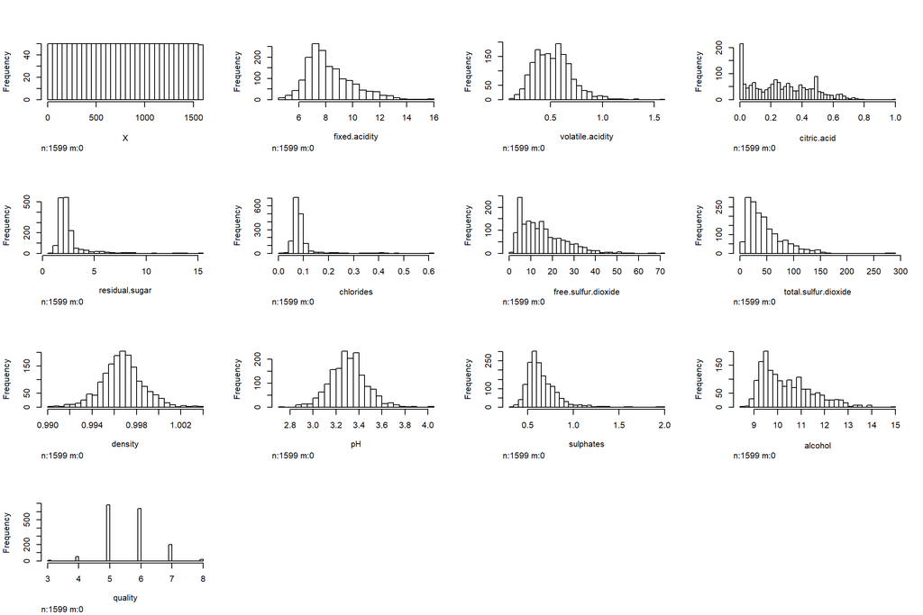

### 数据总览

```
##        X          fixed.acidity   volatile.acidity  citric.acid
##  Min.   :   1.0   Min.   : 4.60   Min.   :0.1200   Min.   :0.000
##  1st Qu.: 400.5   1st Qu.: 7.10   1st Qu.:0.3900   1st Qu.:0.090
##  Median : 800.0   Median : 7.90   Median :0.5200   Median :0.260
##  Mean   : 800.0   Mean   : 8.32   Mean   :0.5278   Mean   :0.271
##  3rd Qu.:1199.5   3rd Qu.: 9.20   3rd Qu.:0.6400   3rd Qu.:0.420
##  Max.   :1599.0   Max.   :15.90   Max.   :1.5800   Max.   :1.000
##  residual.sugar     chlorides       free.sulfur.dioxide
##  Min.   : 0.900   Min.   :0.01200   Min.   : 1.00
##  1st Qu.: 1.900   1st Qu.:0.07000   1st Qu.: 7.00
##  Median : 2.200   Median :0.07900   Median :14.00
##  Mean   : 2.539   Mean   :0.08747   Mean   :15.87
##  3rd Qu.: 2.600   3rd Qu.:0.09000   3rd Qu.:21.00
##  Max.   :15.500   Max.   :0.61100   Max.   :72.00
##  total.sulfur.dioxide    density             pH          sulphates
##  Min.   :  6.00       Min.   :0.9901   Min.   :2.740   Min.   :0.3300
##  1st Qu.: 22.00       1st Qu.:0.9956   1st Qu.:3.210   1st Qu.:0.5500
##  Median : 38.00       Median :0.9968   Median :3.310   Median :0.6200
##  Mean   : 46.47       Mean   :0.9967   Mean   :3.311   Mean   :0.6581
##  3rd Qu.: 62.00       3rd Qu.:0.9978   3rd Qu.:3.400   3rd Qu.:0.7300
##  Max.   :289.00       Max.   :1.0037   Max.   :4.010   Max.   :2.0000
##     alcohol         quality
##  Min.   : 8.40   Min.   :3.000
##  1st Qu.: 9.50   1st Qu.:5.000
##  Median :10.20   Median :6.000
##  Mean   :10.42   Mean   :5.636
##  3rd Qu.:11.10   3rd Qu.:6.000
##  Max.   :14.90   Max.   :8.000
```

## 固定酸

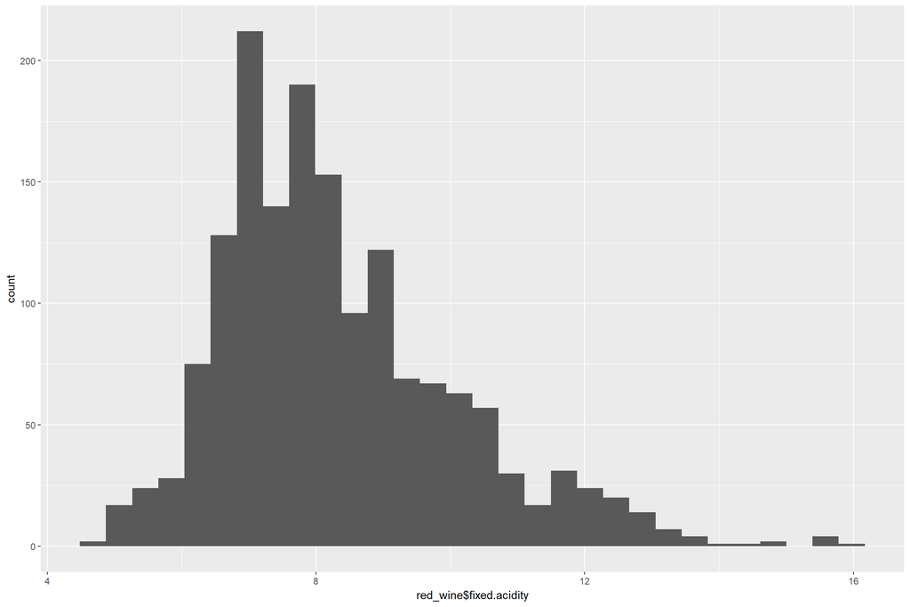

## 挥发酸

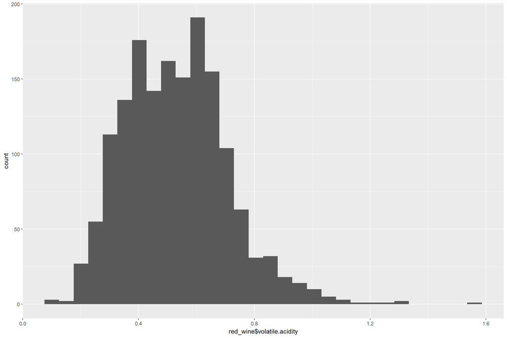

## 柠檬酸

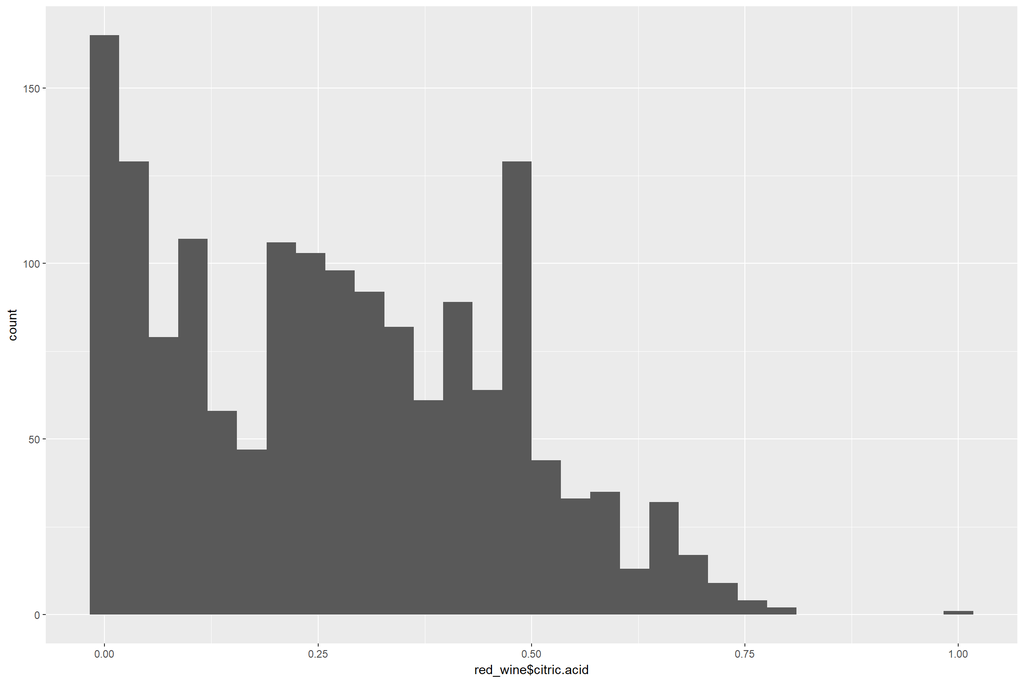

### 柠檬酸分布有些特殊

## 残糖

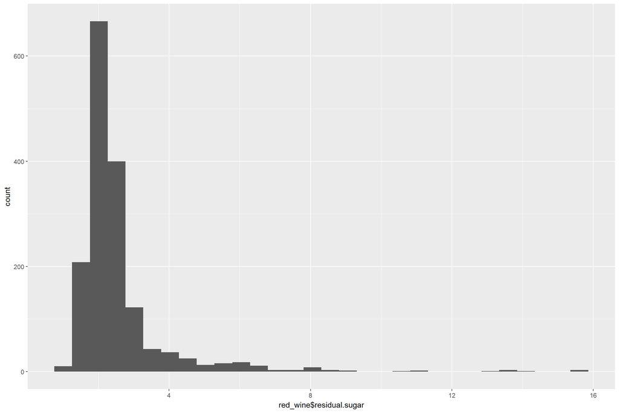

### 甜度差别很大,但没有一款是甜酒.

## 氯化物

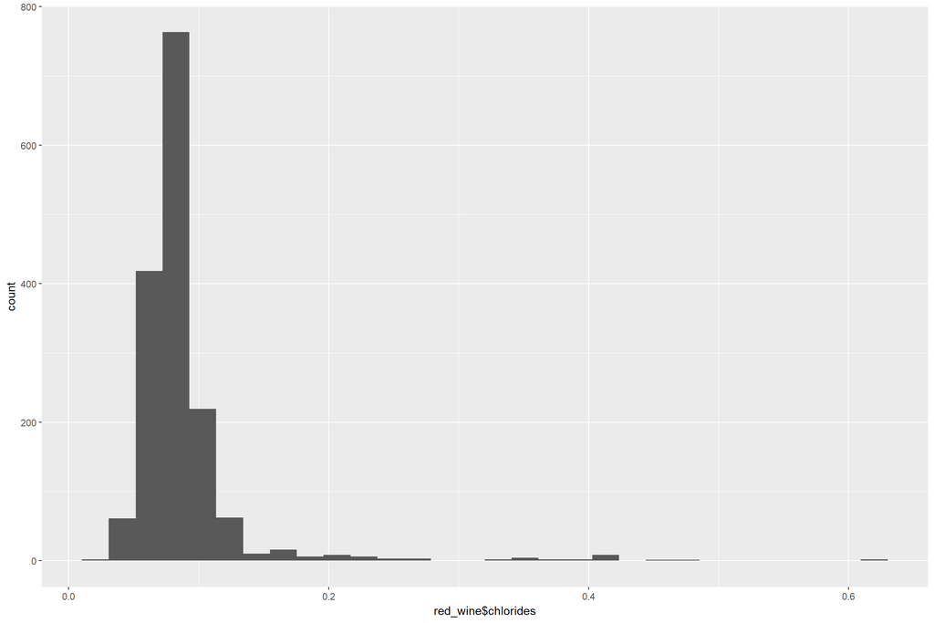

### 氯化物差别很大

## 游离二氧化硫

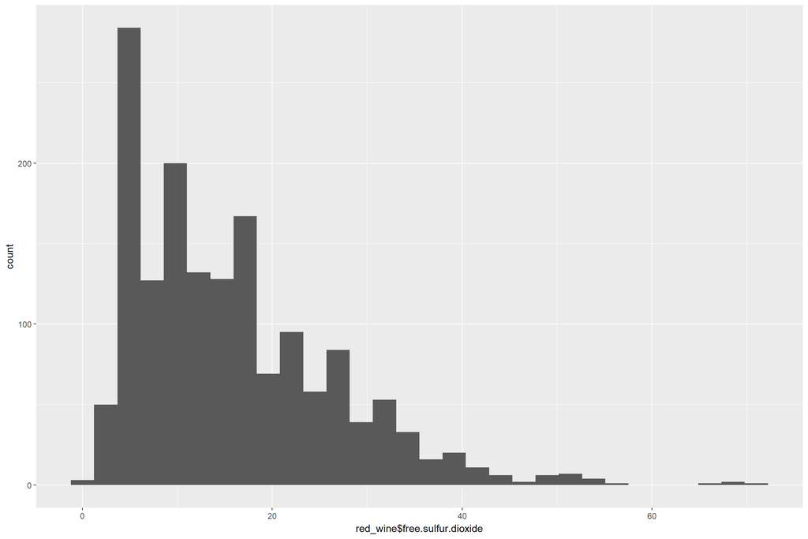

## 总二氧化硫

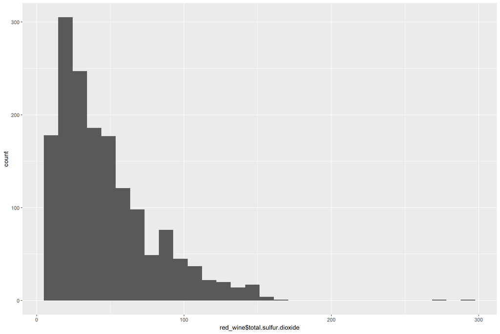

### 总二氧化硫浓度高于游离二氧化硫,符合常识.

## 密度

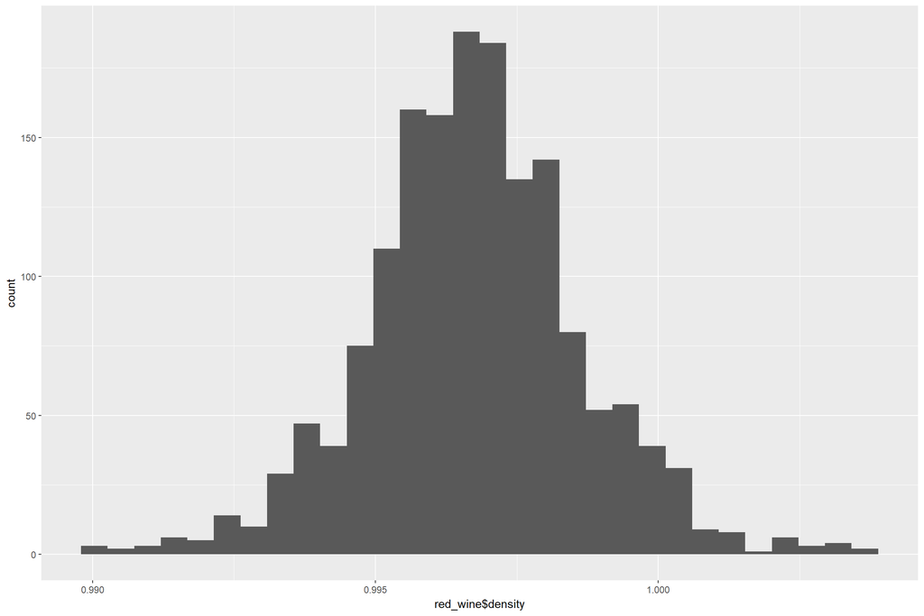

### 密度因素的分布非常接近于正态分布

## PH值

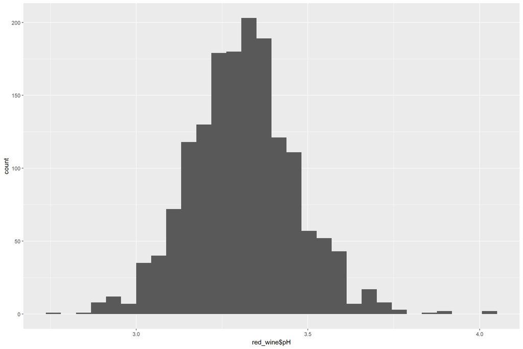

### PH值也是非常接近正态分布

## 硫化物

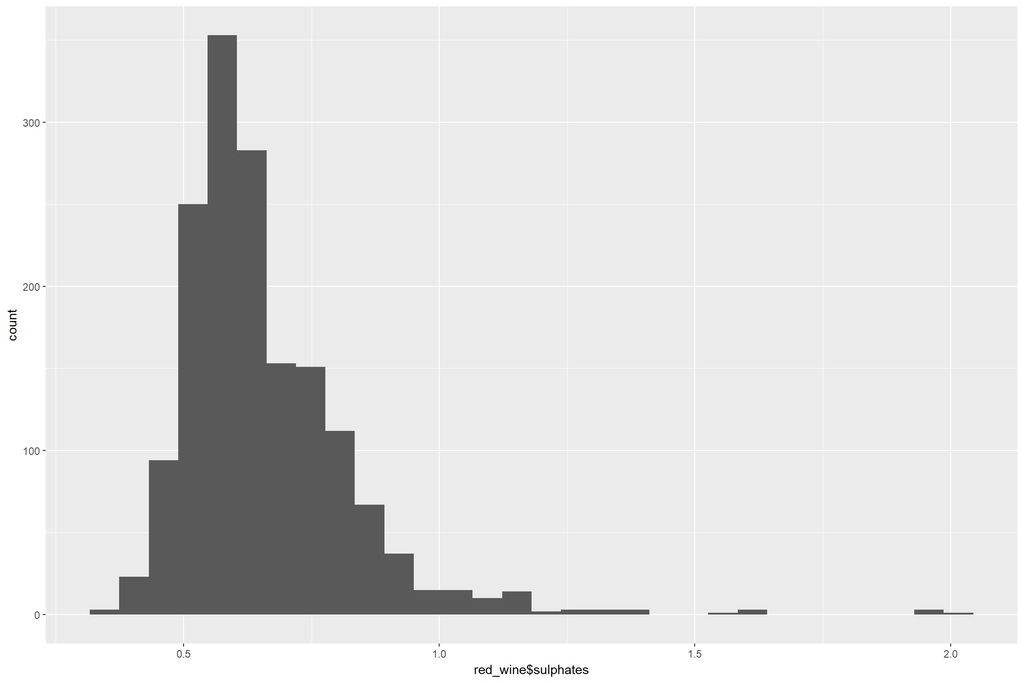

## 酒精

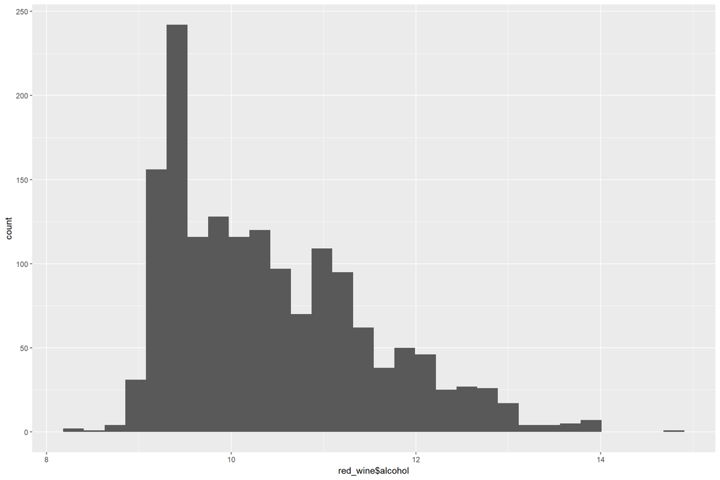

### 红酒属于低度酒

## 质量

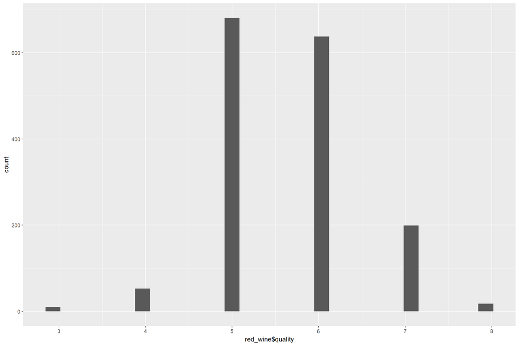

### 大多数红酒的质量为5~6分,符合市场规律.

# 单变量分析

## 1你的数据集结构是?

### 数据集中共有1599种红酒,具有11种化学成分,一个主观质量评分(3~8).

## 2你对数据集内感兴趣的特征?

### 探究影响红酒质量的因素和柠檬酸的特性.

## 3你认为数据集内哪些其他特征可以帮助你探索兴趣特点?

### 与红酒质量相关的因素可能有酒精度,糖类,酸类,二氧化硫.

### 与柠檬酸相关的因素可能有固定酸,挥发酸,pH值.

## 4在已经探究的特性中,是否存在任何异常分布?你是否对数据进行一些操作?

### 柠檬酸的直方图比较特殊,呈现双峰结构.

# 双变量绘图选择

## 散点图矩阵

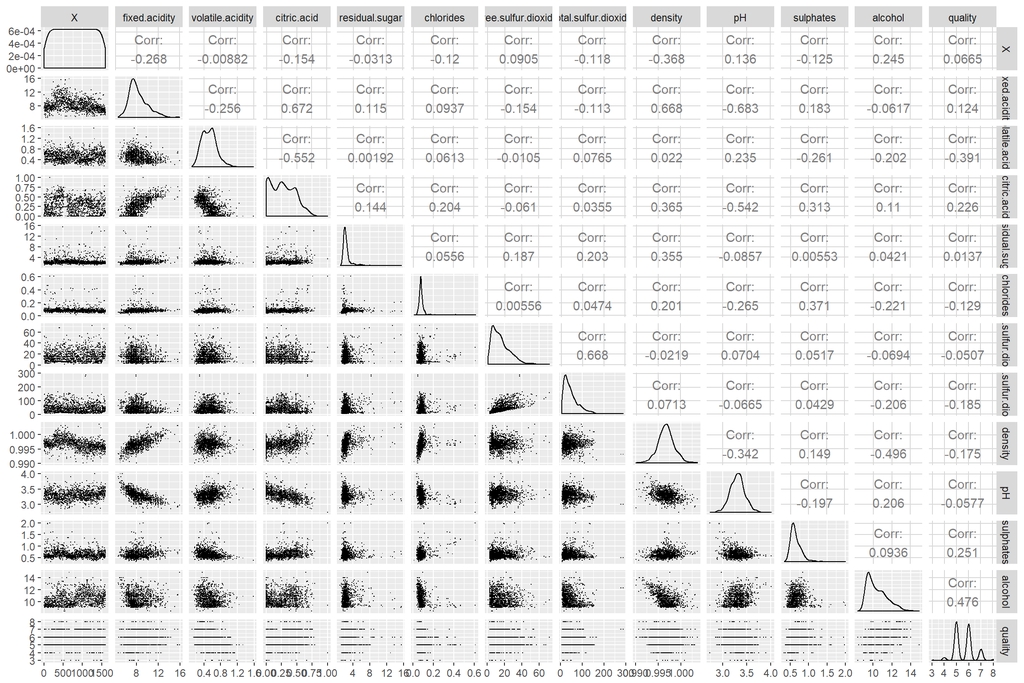

## 1影响质量的主要因素有:

### 挥发酸,柠檬酸,硫酸盐,酒精.

## 2高度相关的因素有:

### 柠檬酸和固定酸,挥发酸

### 柠檬酸和PH值

### 总二氧化硫和游离二氧化硫

### 酒精和密度

### 酒精和质量

## 质量和挥发酸的相关关系:

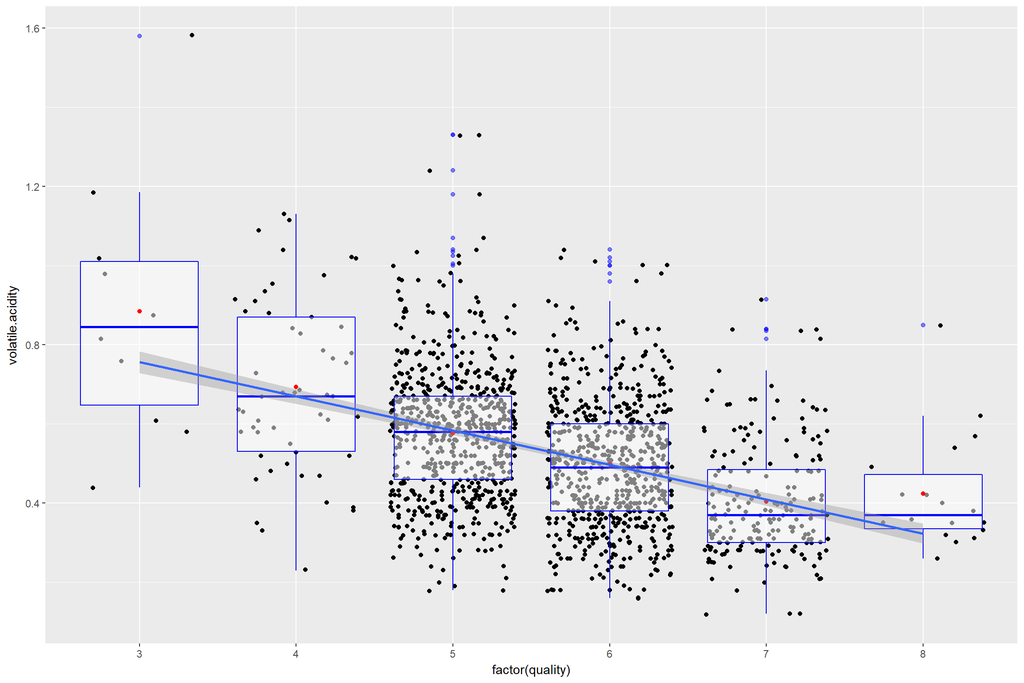

### 质量和挥发酸不是严格的线性相关, 除8级外呈负相关.

## 质量和柠檬酸的相关关系:

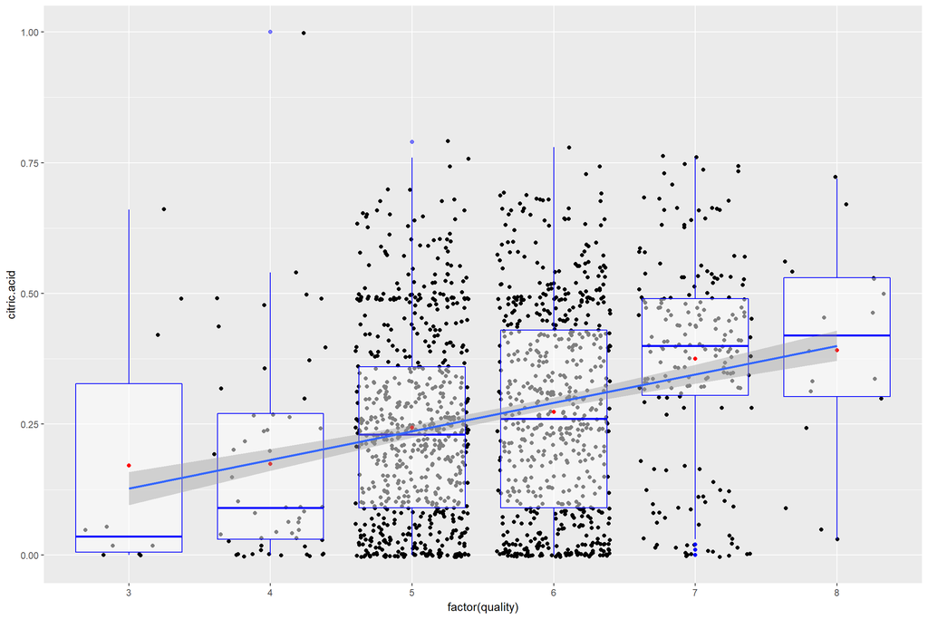

### 质量和柠檬酸呈正相关

## 质量和硫化物的相关关系:

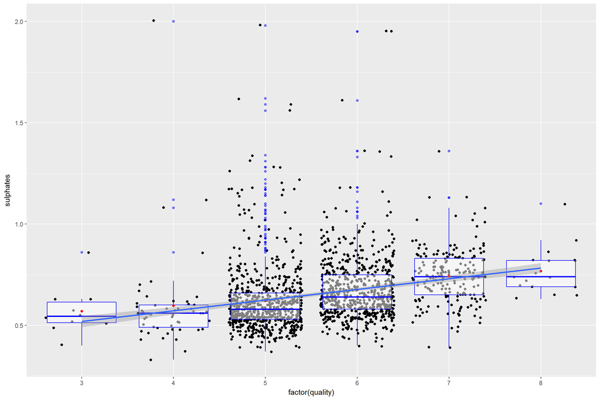

### 质量和硫化物呈正相关

## 质量和酒精的相关关系:

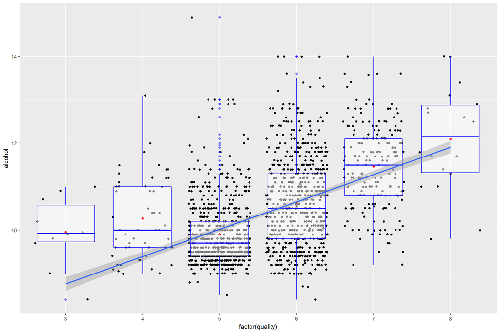

### 质量和酒精不是线性相关,5级之后呈正相关

## 质量和残糖的相关关系:

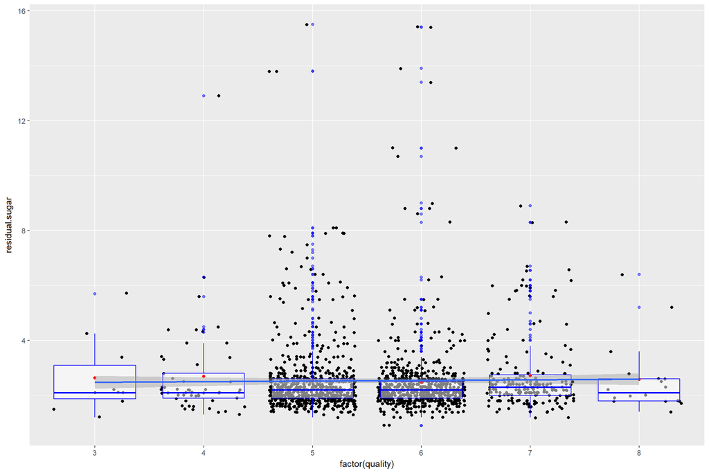

### 散点图矩阵中显示质量和残糖无关,发现确实如此.

## 其他相关关系:

## 柠檬酸和固定酸的相关关系:

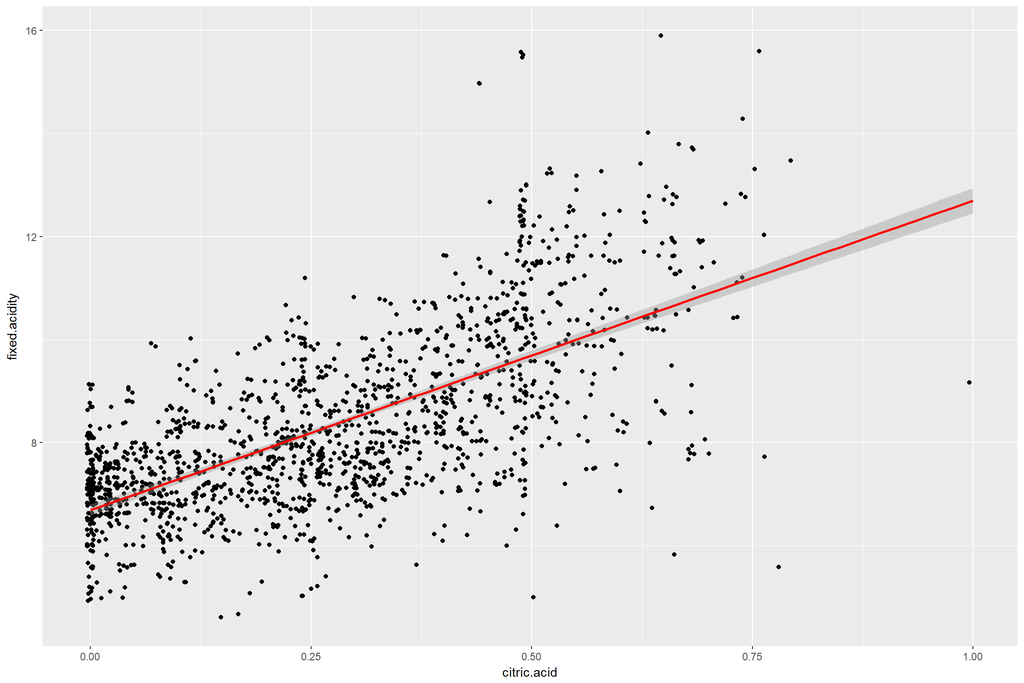

### 柠檬酸和固定酸呈正相关

## 柠檬酸和挥发酸的相关关系:

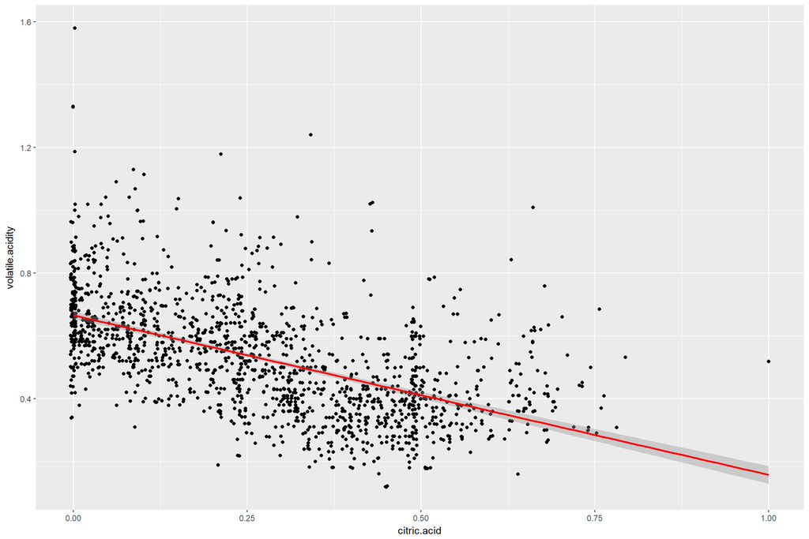

### 柠檬酸和挥发酸呈负相关

## 柠檬酸和PH值的相关关系:

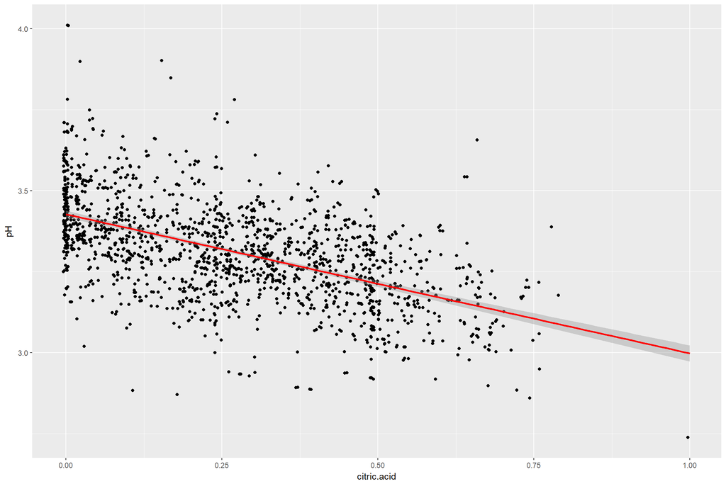

### 柠檬酸和PH值呈负相关

## 总二氧化硫和游离二氧化硫的相关关系:

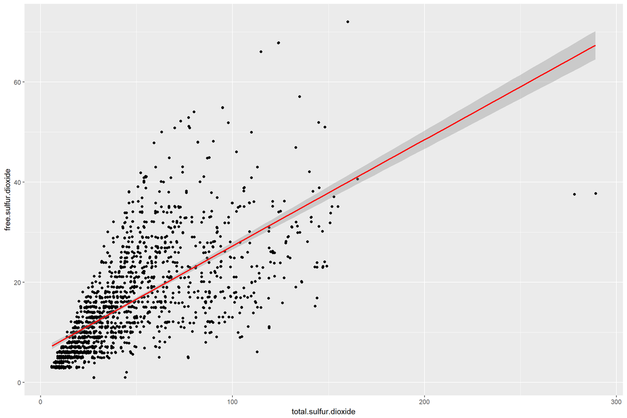

### 总二氧化硫和游离二氧化硫呈正相关

## 酒精和密度的相关关系:

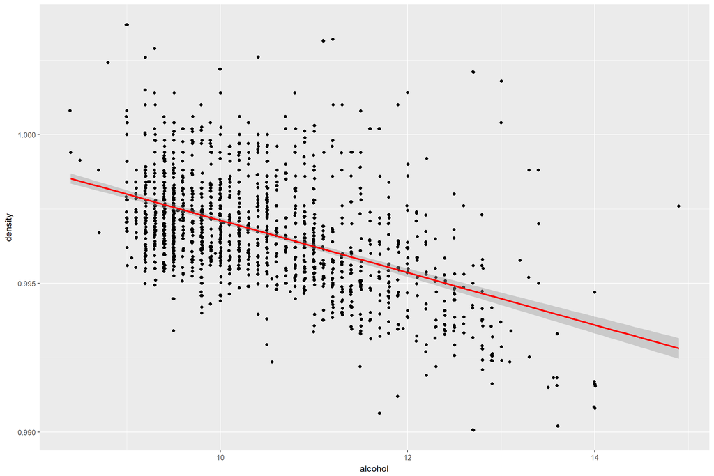

### 酒精和密度呈负相关

# 双变量分析

## 探讨你在这部分探究中观察到的一些关系,这些感兴趣的特性与数据集内其他特性有什么区别?

### 基于散点图矩阵,探究了影响质量的最重要的四个因素,根据相关程度依次为酒精,挥发酸,硫化物和柠檬酸.

### 质量与柠檬酸呈正相关,与硫化物呈正相关.

### 质量和挥发酸不是严格的线性相关, 除8级外呈负相关.

### 质量和酒精不是线性相关,5级之后呈正相关

## 你是否观察到主要特征与其它特征之间有趣的关系?

### 柠檬酸和固定酸呈正相关

### 柠檬酸和挥发酸呈负相关

### 柠檬酸和PH值呈负相关

### 总二氧化硫和游离二氧化硫呈正相关

### 酒精和密度呈负相关

## 你发现的最强关系是什么?

```
##
##  Pearson's product-moment correlation
##
## data:  red_wine$fixed.acidity and red_wine$pH
## t = -37.366, df = 1597, p-value < 2.2e-16
## alternative hypothesis: true correlation is not equal to 0
## 95 percent confidence interval:
##  -0.7082857 -0.6559174
## sample estimates:
##        cor
## -0.6829782
```

### 最强相关为固定酸和PH值,皮尔森相关系数约为-0.68.

# 多变量绘图选择

### 固定酸和挥发酸在不同质量下的相关关系:

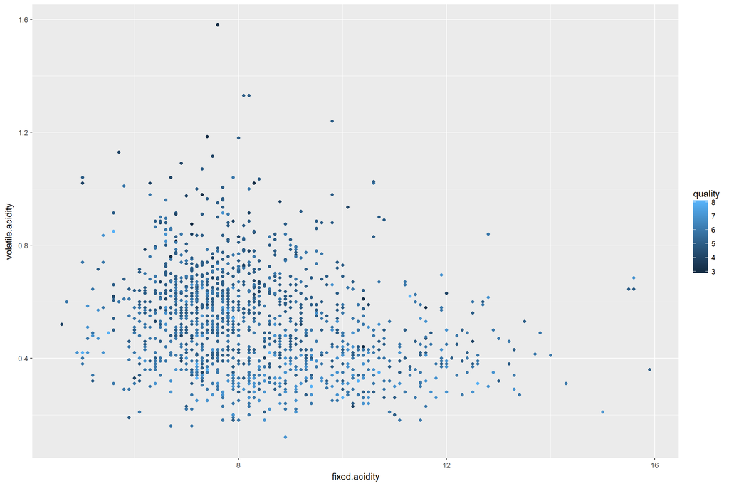

### 高品质红酒多集中在挥发酸低的区域的区域.

## 柠檬酸和酸类在不同质量下的相关关系:

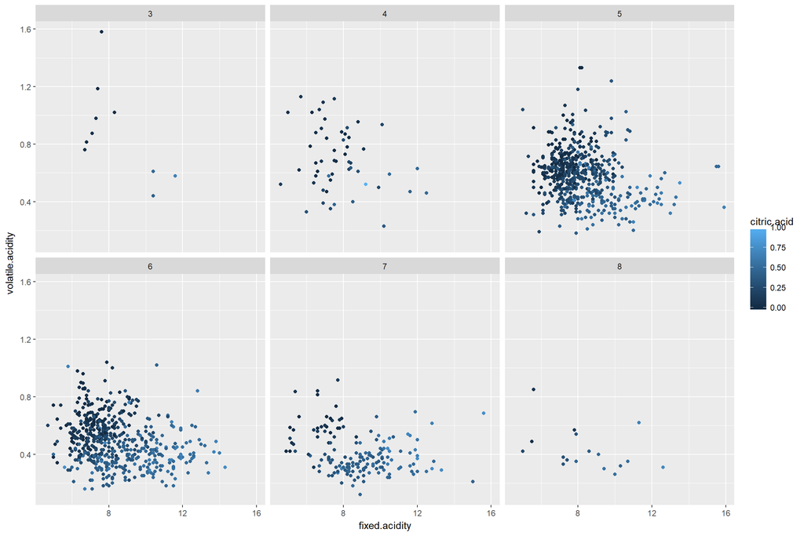

### 高柠檬酸总出现在挥发酸少的区域,并倾向于出现在高固定酸区域.

## 总二氧化硫,游离二氧化硫和硫化物在不同质量下的相关关系:

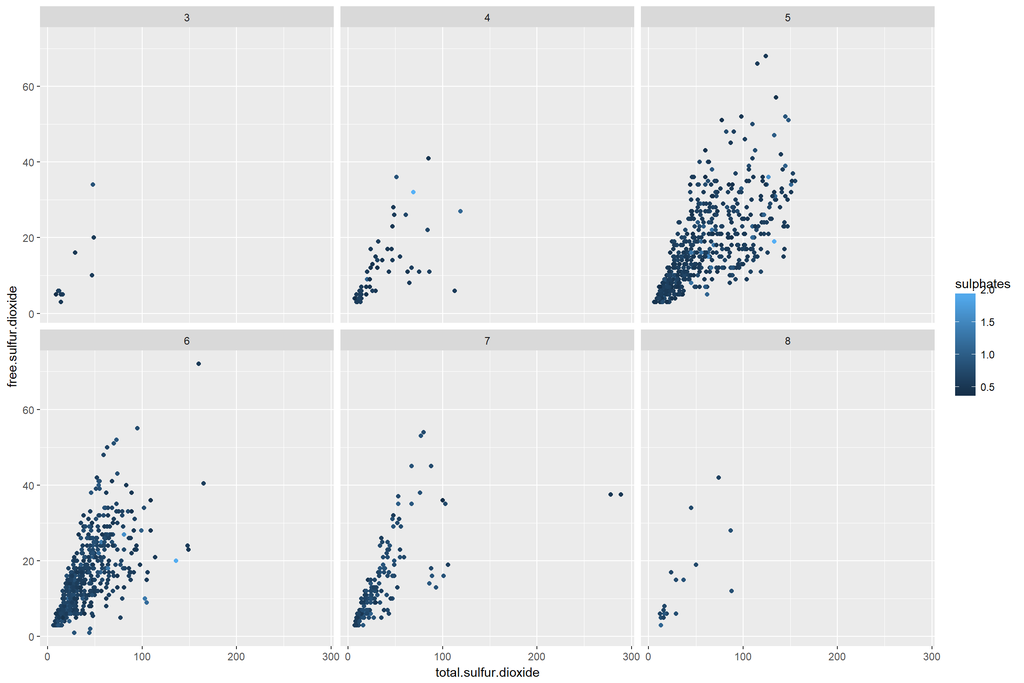

### 总二氧化硫和游离二氧化硫正相关

## 密度酒精和残糖在不同质量下的相关关系:

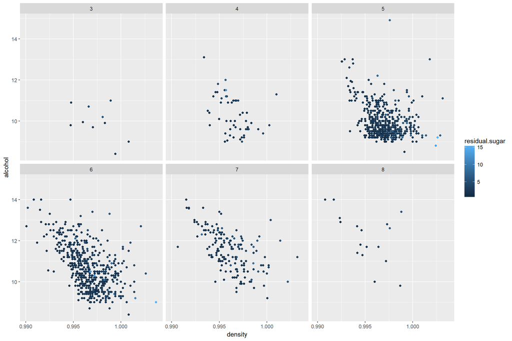

### 高质量酒出现在酒精度高区域,高残糖出现在高密度区域.

## 酒精和密度在不同质量下的相关关系:

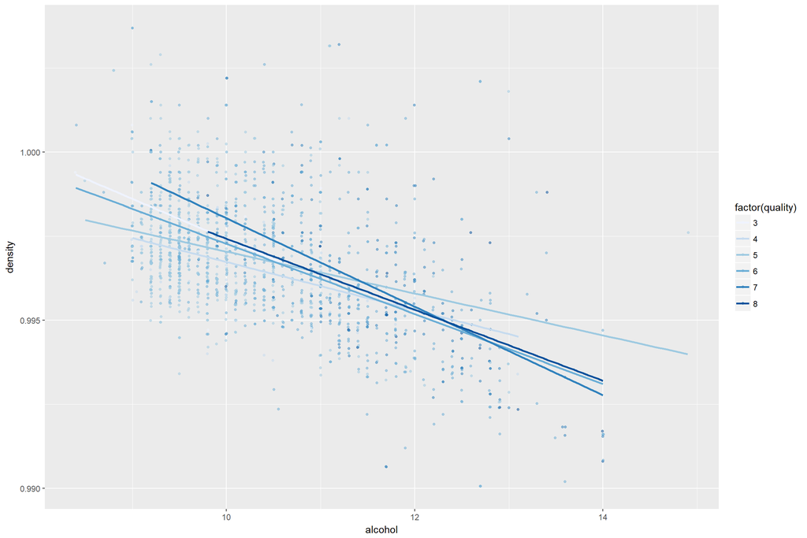

### 不同质量的红酒,都是酒精和密度呈负相关.

# 多变量分析

## 探讨你在这部分探究中观察到的一些关系,通过观察感兴趣的特性,是否存在相互促进的特性?

### 高品质红酒多集中在挥发酸低的区域的区域.

### 高柠檬酸总出现在挥发酸少的区域,并倾向于出现在高固定酸区域.

### 总二氧化硫和游离二氧化硫正相关,未发现和硫化物的关系.

### 高质量酒出现在酒精度高区域,高残糖出现在高密度区域.

### 不同质量的红酒,都是酒精和密度呈负相关.

### 猜测柠檬酸和固定酸有促进作用,总二氧化硫和游离二氧化硫有促进作用.

### 猜测高残糖和低酒精对高密度有促进作用.

## 这些特性之间是否存在有趣或惊人的联系呢?

### 残糖不会影响酒精度.

### 没有挥发酸和固定酸同时特别高的红酒,也许二者可以单向转化.

### 柠檬酸可能是固定酸的一种.

### 总二氧化硫可能生成游离二氧化硫.

### 密度也许由残糖和酒精决定.

# 定稿图和总结

## 绘图一:

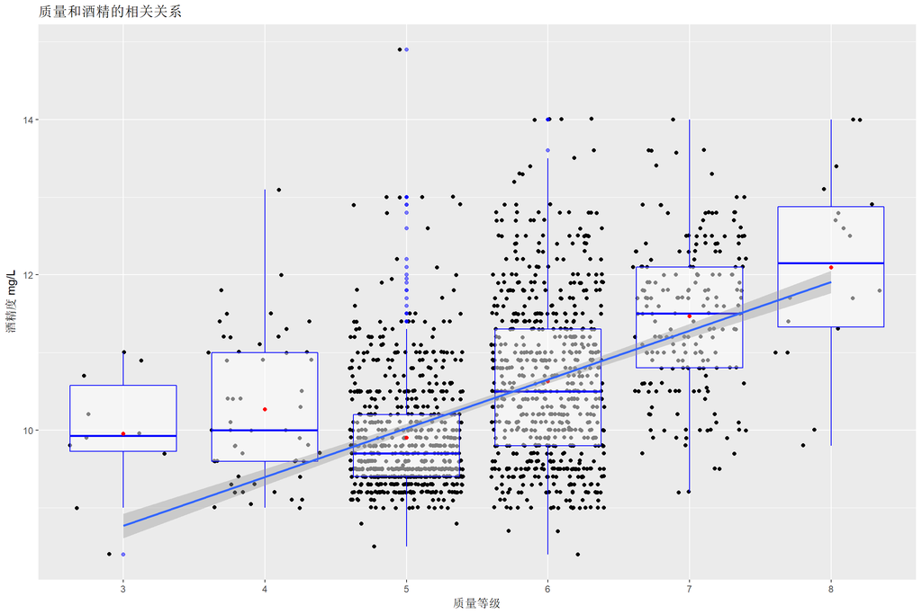

## 描述一:

### 质量和酒精度呈正相关

## 绘图二:

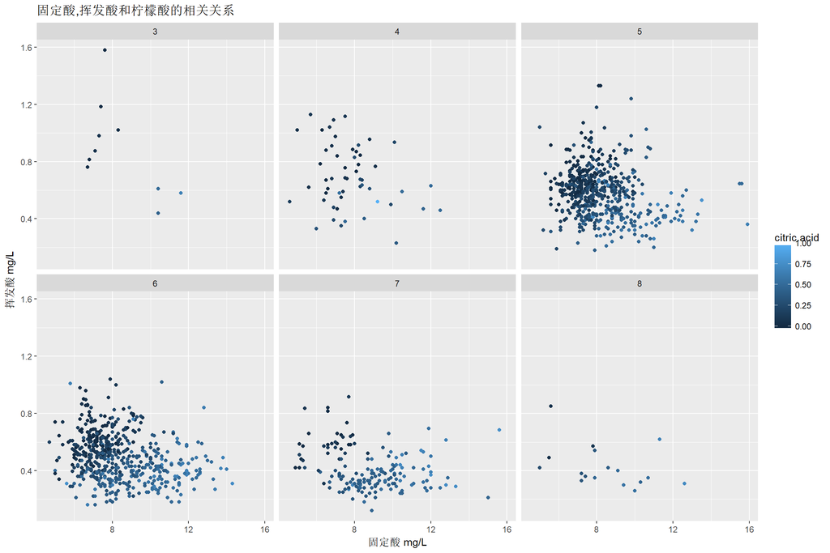

## 描述二:

### 高柠檬酸总出现在挥发酸少的区域,并倾向于出现在高固定酸区域.

## 绘图三:

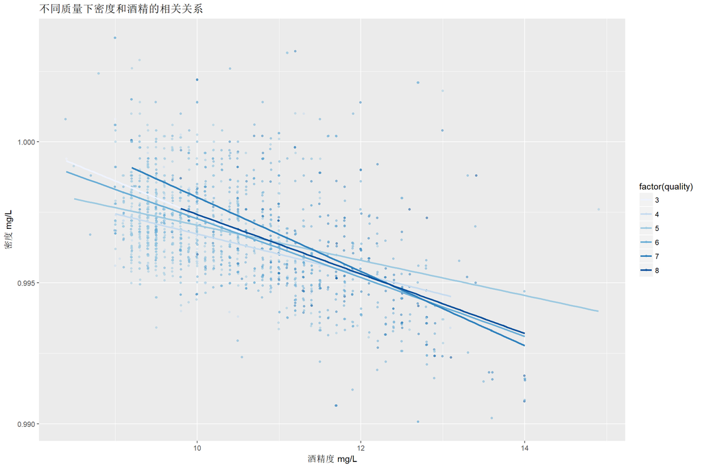

## 描述三:

### 不同质量的红酒,都是酒精和密度呈负相关.

# 反思:

### 分析过程中,特别依赖于散点图矩阵和相关系数.思路不够开阔.